# Artificial Intelligence Course - Fall 1402

## Computer Assignment #2 - Reinforcement Learning

- Part 1: Value Iteration & Policy Iteration Algorithms
  - َQuestion 1:
  - َQuestion 2:
  - َQuestion 3:
  - َQuestion 4:
  - Question 5:
    - Value Iteration
    - Policy Iteration
  - Question 6:
- Part 2: Q-Learning Algorithm
  - َQuestion 8:
  - َQuestion 9:
  - َQuestion 10:

```python
# import
import numpy as np
import matplotlib.pyplot as plt
import gymnasium as gym
from time import sleep, time
from typing import *
```

```python
EPSILON = 0.1
LEARNING_RATE = 0.1
DISCOUNT = 0.9
DECAY_RATE = 0.1

# Q-learning parameters
REPS = 5
EPISODES = 500
TIME_LIMIT = 200

DO_RENDER = True
RENDER_FPS = 10

STUDENT_NUM = 573
```

```python
def monitor_time(f: Callable):
    start = time()
    result = f()
    end = time()
    return result, end - start
```

## Part 1: Value Iteration & Policy Iteration Algorithms

### Question 1: How does value iteration algorithm find the optimal policy on Markov decision processes(MDPs)?

Basically to solve an MDP, it is necessary to find an optimal policy for each state. One way to find it is to solve an $n$-equations-$n$-unknowns system over utility values of each state where $n$ is the number of states. The equations' form is as follows: $$ U(s) = \max_{a \in Actions} \sum_{s' \in States} Pr(s'|s,a) \bigg(R(s, a, s') + \gamma U(s')\bigg) $$ for all $s \in States$ where $U(s)$ is the utility measure of state $s$, $Pr(s'|s, a)$ is the probability of ending up in $s'$ after taking action $a$ in state $s$, and $R(s, a, s')$ is the reward of taking action $a$ from state $s$ and ending up in $s'$.

Now, Imagine $U_i$ where: $$ U_{i+1}(s) \leftarrow \max_{a \in Actions} \sum_{s' \in States} Pr(s'|s,a) \bigg(R(s, a, s') + \gamma U_i(s')\bigg) $$ and $$ U_0(s) = 0 $$ with aforementioned definitions for $Pr$ and $R$. It is provable that $U_i(s)$ will converge on a value for each $s \in States$.

As a result of this convergence, value iteration algorithm thrives. It calculates $U_{i+1}(s)$ for as many times as needed to at last, have the following inequality: $$\max_{s \in States} |U_{i+1}(s) - U_i(s)| < \theta$$ where $\theta$ is the *error* measure.

Once $U(s)$ values for all $s \in States$ are collected, the optimal policy $\pi(s)$ will be calculated as described below: $$ \pi(s) = \argmax_{a \in Actions} \sum_{s' \in States} Pr(s'|s,a) \bigg(R(s, a, s') + \gamma U_i(s')\bigg) .$$

Notice that for the sake of simplifying and breaking the equations down to understandable pieces, $Q(s, a)$ is frequently used which is defined as follows: $$ Q(s, a) = \sum_{s' \in States} Pr(s'|s,a) \bigg(R(s, a, s') + \gamma U(s')\bigg) .$$

### Question 2: Complete the given `ValueIterationAgent` class.

```python
class ValueIterationAgent:
    def __init__(self: Self, env: gym.Env, discount_factor: float, theta:float=1e-8):
        self.env = env
        self.discount_factor = discount_factor
        self.theta = theta
        self.state_values = np.zeros(env.observation_space.n)
        self.q_values = np.zeros((env.observation_space.n,
                    env.action_space.n))

        self.is_value_estimated = False

    def value_estimation(self: Self):
        if self.is_value_estimated:
            return
        env, state_values, q_values, discount_factor, theta = \
                self.env, \
                self.state_values, \
                self.q_values, \
                self.discount_factor, \
                self.theta

        delta = np.inf

        while(delta > theta):
            delta = 0

            for state in range(env.observation_space.n):
                previous_state_value = state_values[state]

                for action in range(env.action_space.n):
                    action_value = 0
                    for probability, next_state, reward, _ in env.unwrapped.P[state][action]:
                        action_value += probability * \
                                (reward + \
                                discount_factor * state_values[next_state])
                    q_values[state, action] = action_value

                state_values[state] = np.max(q_values[state,:])

                delta = np.max([delta, abs(previous_state_value - state_values[state])])

        self.is_value_estimated = True

    def take_action(self: Self, action: Any):
        next_state, reward, terminated, truncated, _ = self.env.step(action)
        return next_state, reward, terminated, truncated

    def get_optimal_policy(self: Self, state: Any):
        return np.argmax(self.q_values[state,:])

    def get_state_values(self: Self):
        return self.state_values

    def get_q_values(self: Self):
        return self.q_values

    def reset(self: Self, *args, **kwargs):
        initial_state, _ = self.env.reset(*args, **kwargs)
        return initial_state, False, False

    def __repr__(self: Self):
        env = self.env
        nrow, ncol = env.unwrapped.nrow, env.unwrapped.ncol
        n = env.observation_space.n

        self.value_estimation()
        to_format = np.vectorize(lambda x: f"{x:.3f}")
        state_values = to_format(self.get_state_values()).reshape(nrow, ncol)
        optimal_policy = np.array([self.get_optimal_policy(state) for state in range(n)]).reshape(nrow, ncol)
        st = "\n".join(["-" * 10,
                "State Utilities:",
                str(state_values),
                "Optimal Policy:",
                str(optimal_policy),
                "-" * 10])
        return st

    __str__ = __repr__
```

### Question 3: How does policy iteration algorithm find the optimal policy on MDPs?

In order to find the optimal policy for each state, there is another way rather than solving foretold equations. In policy iteration algorithm we start with a random policy function $$ \pi_0: States \rightarrow Actions,$$ and $$ U^{\pi_0}(s) = 0.$$ In each step, thereafter, with the purpose of improving our policy, policy iteration algorithms carry out two procedures:

- **policy evaluation**, which evaluates $U^{\pi_i}$ for each policy,
- **policy improvement**, which improves $\pi_i$ and gives $\pi_{i+1}: States \rightarrow Actions$.

For policy improvement, it uses the following method: $$ \pi_{i+1}(s) \leftarrow \argmax_{a \in Actions} \sum_{s' \in States} Pr(s'|s, a) \bigg(R(s, a, s') + \gamma U^{\pi_i}(s)\bigg) .$$

For policy evaluation, we must solve an $n$-equations-$n$-unknowns system that is as follows: $$ U^{\pi_i}(s) = \sum_{s' \in States} Pr(s'|s, \pi_i(s)) \bigg(R(s, \pi_i(s), s') + \gamma U^{\pi_i}(s)\bigg) $$ where $n$ is $|States|$. However, unlike value iteration, this time because there is no non-linear function such as $max$, the equation system is linear and, therefore, soluable by *Gaussian elimination method*(or *Gauss-Jordan method*) with $O(n^3)$ time complexity. Even though Gaussian elimination method is quite practical in small environments, it takes too long to be carried out on a big one. Thankfully, there is another way. If we define $U_j^{\pi_i}$ so that: $$ U_{j+1}^{\pi_i}(s) \leftarrow \sum_{s' \in States} Pr(s'|s, \pi_i(s)) \bigg(R(s, \pi_i(s), s') + \gamma U_j^{\pi_i}(s)\bigg) ,$$ where $\forall s \in States\bigg(U_0^{\pi_i}(s) = 0\bigg)$, it is provable that $U_j^{\pi_i}$ converges on the answer of the equations. This procedure is called *simplified value iteration* and if a policy iteration algorithm uses it, it will be called a *modified policy iteration algorithm*. In this assignment, the second approach is used.

### Question 4: Complete the given `ModifiedPolicyIterationAgent` class.

```python
class ModifiedPolicyIterationAgent():
    def __init__(self: Self, env: gym.Env, discount_factor:float, theta:float=1e-8):
        self.env = env
        self.discount_factor = discount_factor
        self.theta = theta
        self.state_values = np.zeros((env.observation_space.n))
        self.q_values = np.zeros((env.observation_space.n, env.action_space.n))
        self.policy = np.random.randint(env.action_space.n, size=env.observation_space.n)
        self.policy_stable = False

    def policy_evaluation(self):
        env, discount_factor, theta, state_values, policy = self.env, \
                self.discount_factor, \
                self.theta, \
                self.state_values, \
                self.policy
        delta = np.inf

        while(delta > theta):

            delta = 0

            for state in range(env.observation_space.n):

                previous_state_value = state_values[state]

                new_state_value = 0
                for probability, next_state, reward, _ in env.unwrapped.P[state][policy[state]]:
                    new_state_value += probability * \
                                (reward + \
                                discount_factor * state_values[next_state])
                state_values[state] = new_state_value

                delta = np.max([delta, abs(previous_state_value - new_state_value)])

    def policy_improvement(self: Self):
        env, discount_factor, state_values, q_values, policy = self.env, \
                self.discount_factor, \
                self.state_values, \
                self.q_values, \
                self.policy

        is_policy_stable = True
        for state in range(env.observation_space.n):
            old_policy = policy[state]

            for action in range(env.action_space.n):

                action_value = 0
                for probability, next_state, reward, _ in env.unwrapped.P[state][action]:
                    action_value += probability * \
                                (reward + \
                                discount_factor * state_values[next_state])
                q_values[state, action] = action_value

            policy[state] = np.argmax(q_values[state,:])

            if old_policy != policy[state]:
                is_policy_stable = False

        self.policy_stable = is_policy_stable

    def policy_estimation(self: Self):

        while not self.policy_stable:
            self.policy_evaluation()
            self.policy_improvement()

    def take_action(self: Self, action: Any):
        next_state, reward, terminated, truncated, _ = self.env.step(action)
        return next_state, reward, terminated, truncated

    def get_optimal_policy(self: Self, state):
        return self.policy[state]

    def get_state_values(self: Self):
        return self.state_values

    def get_q_values(self: Self):
        return self.q_values

    def reset(self: Self, *args, **kwargs):
        initial_state, _ = self.env.reset(*args, **kwargs)
        return initial_state, False, False

    def __repr__(self: Self):
        env, policy = self.env, self.policy
        nrow, ncol = env.unwrapped.nrow, env.unwrapped.ncol
        n = env.observation_space.n

        self.policy_estimation()
        to_format = np.vectorize(lambda x: f"{x:.3f}")
        state_values = to_format(self.get_state_values()).reshape(nrow, ncol)
        optimal_policy = np.array(policy).reshape(nrow, ncol)
        st = "\n".join(["-" * 10,
                "State Utilities:",
                str(state_values),
                "Optimal Policy:",
                str(optimal_policy),
                "-" * 10])
        return st

    __str__ = __repr__
```

### Question 5: Run both algorithms on the Frozen Lake environment.

#### Value Iteration:

```python
env = gym.make('FrozenLake-v1',
        desc=None,
        map_name="4x4",
        is_slippery=True,)

agent = ValueIterationAgent(env, DISCOUNT)
agent.value_estimation()
agent
```

```
----------
State Utilities:
[['0.069' '0.061' '0.074' '0.056']
 ['0.092' '0.000' '0.112' '0.000']
 ['0.145' '0.247' '0.300' '0.000']
 ['0.000' '0.380' '0.639' '0.000']]
Optimal Policy:
[[0 3 0 3]
 [0 0 0 0]
 [3 1 0 0]
 [0 2 1 0]]
----------
```

#### Policy Iteration:

```python
env = gym.make('FrozenLake-v1',
        desc=None,
        map_name="4x4",
        is_slippery=True)

agent = ModifiedPolicyIterationAgent(env, DISCOUNT)
agent.policy_estimation()
agent
```

```
----------
State Utilities:
[['0.069' '0.061' '0.074' '0.056']
 ['0.092' '0.000' '0.112' '0.000']
 ['0.145' '0.247' '0.300' '0.000']
 ['0.000' '0.380' '0.639' '0.000']]
Optimal Policy:
[[0 3 0 3]
 [0 0 0 0]
 [3 1 0 0]
 [0 2 1 0]]
----------
```

### Question 6: Compare the returned state values and policies of value iteration and policy iteration. Next, answer which one has been quicker.

As shown in the previous section, state utility values and optimal policies for both algorithms have converged on a single result — which is intuitively obvious since if they had converged onto two different results, it would have been contradictory to the very definition of convergence itself.

Also, to be able to measure the time taken by each agent, each will be run `REPS` times, every time assessed by the `monitor_time` function. This function is designed to return any function's running duration. Next, these assessments will be averaged and printed.

In addition, in order to obtain a better comparative understanding about policy iteration and value iteration, we use $8\times8$ Frozen Lake map to calculate the time taken by each. In other words, we do so to reduce effects of noises caused by the OS and/or hardware.

```python
average_value_estimation_time = 0
average_policy_estimation_time = 0
for i in range(REPS):
    env = gym.make('FrozenLake-v1',
            desc=None,
            map_name="8x8",
            is_slippery=True)

    value_iterative_agent = ValueIterationAgent(env, DISCOUNT)
    policy_iterative_agent = ModifiedPolicyIterationAgent(env, DISCOUNT)

    _, value_estimation_time = monitor_time(lambda: value_iterative_agent.value_estimation())
    _, policy_estimation_time = monitor_time(lambda: policy_iterative_agent.policy_estimation())

    average_value_estimation_time += value_estimation_time
    average_policy_estimation_time += policy_estimation_time

average_value_estimation_time /= REPS
average_policy_estimation_time /= REPS

average_value_estimation_time, average_policy_estimation_time
```

```
(0.10686173439025878, 0.20636992454528807)
```

```python
f"utility(policy iteration) / utility(value iteration): {(average_value_estimation_time / average_policy_estimation_time) * 100:.3f}%"
```

```
'utility(policy iteration) / utility(value iteration): 51.782%'
```

As you can see, value iteration algorithm wins the race by almost doubling the efficiency.

To close the first part in style, a graphical representation of an agent taking the optimal policy to the goal is provided.

```python
if DO_RENDER:
    env = gym.make('FrozenLake-v1',
            desc=None,
            map_name="4x4",
            is_slippery=True,
            render_mode='human' if DO_RENDER else None)
    env.metadata['render_fps'] = RENDER_FPS

    agent = ValueIterationAgent(env, DISCOUNT)
    agent.value_estimation()
    state, terminated, truncated = agent.reset(seed=STUDENT_NUM)
    try:
        while not (terminated or truncated):
            action = agent.get_optimal_policy(state)
            state, _, terminated, truncated = agent.take_action(action)
            env.render()
    finally:
        env.close()
```

## Part 2: Q-Learning Algorithm

### Question 7: How does temporal-difference Q-Learning algorithm work?

Q-Learning algorithm learns Q-value of each $(state, action)$ by applying the following assignment every time action $a$ is perceived transitioning state $s$ to $s'$. ($Q(s, a)$ is initially zero for all $(s, a)$) $$ Q(s, a) \leftarrow Q(s, a) + \alpha[R(s, a, s') + \gamma \max_{a'} Q(s', a') - Q(s, a)] $$ where $\alpha$ and $\gamma$ are the learning rate and the discounting factor respectively. Now the question is how the agent chooses actions in each state during the learning process. It is determined by the following function: $$ f(Q, s, p) := \begin{cases} random\_choice(Actions) & \text{if } p < \epsilon \\ \max_{a\in Actions} Q(s, a) & \text{o.w.} \end{cases} $$ where p is a random number in $[0, 1)$. This policy is called $\epsilon$-greedy as it greedily tries to set a balance between exploration and exploitation. In order to quicken the progress towards the convergence, both $\epsilon$ and $\alpha$(learning rate) should be decreasing as epoch number, $n$, grows. Intuitively, it makes sense because with higher epoch numbers our knowledge of the environment had gotten more comprehensive.

Once Q-Learning process is over, optimal policy $\pi^*$ for each $s\in States$ is evaluated the following way: $$ \pi^*(s) = \max_{a\in Actions} Q(s, a) .$$

### Question 8: Complete the given `QLearningAgent` class.

Just before jumping into implementation, the following approaches for $\epsilon$ and $\alpha$ are taken so that we could derive the convergence faster: $$ \epsilon_n = \epsilon_{n - 1} \bigg(\frac{1 + d \times (n - 1)}{1 + d \times n}\bigg) \text{ for } n > 0, $$ $$ \alpha_n = \alpha_0 \bigg(\frac{1}{1 + d \times n}\bigg) \text{ for } n > 0 .$$ where $d$ is the decaying factor. (Notice that these two sequences given $\alpha_0 = \epsilon_0$ are identical: only for $\epsilon$, a recursive formula is used whilst for $\alpha$ a closed formula is used)

In order to illustrate what $\epsilon$ value each episode uses, the following figure is provided.

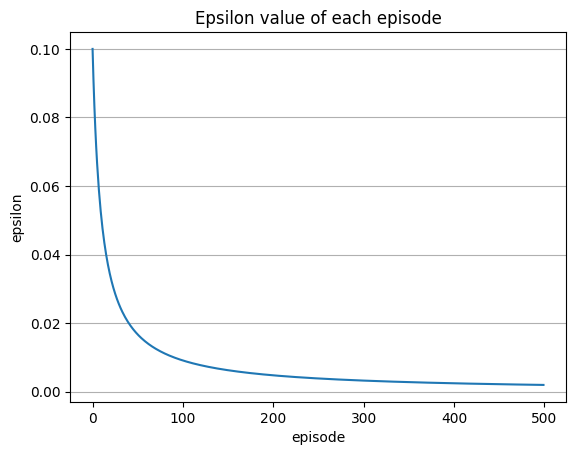

```python
epsilon = lambda n: EPSILON / (1 + DECAY_RATE * n)
vectorized_epsilon = np.vectorize(epsilon)

fig, ax = plt.subplots()
ax.plot(vectorized_epsilon(np.arange(EPISODES)))
ax.grid(True, axis='y')
ax.set_xlabel('episode')
ax.set_ylabel('epsilon')
ax.set_title('Epsilon value of each episode')
plt.show()
```

```python
class QLearningAgent:
    def __init__(self: Self,
                env: gym.Env,
                epsilon: float,
                learning_rate: float,
                discount_factor: float,
                seed: int):
        self.env = env
        self.epsilon = epsilon
        self.learning_rate = learning_rate
        self.olr = learning_rate
        self.discount_factor = discount_factor
        self.q_table = np.zeros((env.observation_space.n, env.action_space.n))
        self.seed = seed
        self.rng = np.random.default_rng()

    def choose_action(self: Self, state: int):
        env, epsilon, q_table, rng = self.env, self.epsilon, self.q_table, self.rng

        decision = rng.random() <= epsilon
        action = rng.integers(env.action_space.n) if decision else np.argmax(q_table[state])

        return action

    def update_q_table(self: Self, state: int, action: int, next_state: int, reward: float):
        a, q_table, discount = self.learning_rate, self.q_table, self.discount_factor
        q_table[state, action] = q_table[state, action] \
                + a * (\
                        (reward + discount * np.max(q_table[next_state])) \
                        - q_table[state, action])

    def decay_epsilon(self: Self, episode: int):
        self.epsilon *= (1 + episode * DECAY_RATE) / (1 + (episode + 1) * DECAY_RATE)

    def decrease_learning_rate(self: Self, episode: int):
        self.learning_rate = self.olr / (1 + (episode + 1) * DECAY_RATE)

    def take_action(self: Self, action: int):
        next_state, reward, terminated, truncated, _ = self.env.step(action)
        return next_state, reward, terminated, truncated

    def get_optimal_policy(self: Self, state: int):
        return np.argmax(self.q_table[state])

    def get_q_values(self: Self):
        return self.q_table

    def reset(self: Self):
        initial_state, _ = self.env.reset(seed=self.seed, )
        return initial_state, False, False

    def __repr__(self: Self):
        env = self.env
        nrow, ncol, npass, nact = 5, 5, 5, 4
        n = env.observation_space.n
        q_values = self.get_q_values()

        to_format = np.vectorize(lambda x: f"{x:.3f}")
        state_values = to_format(np.max(q_values, axis=1)).reshape(nrow, ncol, npass, nact)
        optimal_policy = np.argmax(q_values, axis=1).reshape(nrow, ncol, npass, nact)
        st = "\n".join(["-" * 10,
                "State Utilities:",
                str(state_values),
                "Optimal Policy:",
                str(optimal_policy),
                "-" * 10])
        return st

    __str__ = __repr__
```

### Question 9: Running Q-Learning algorithm for learning rate of 0.1, and for a decaying learning rate. Next, compare them with each other.

Because each of `do_learning`, `show_average_reward`, and `show_convergence` functions are run twice, they are implemented separately:

- `do_learning` is where the algorithm learns the environment `REPS` times each by `EPISODES` training episodes to provide at last `reward_sum` where `reward_sum[r, e]` represents the accumulative reward obtained in repetion `r`, episode `e`. It could be run in two ways:
  - `does_lr_decay == False`: [$\alpha_n =$ `LEARNING_RATE`].
  - `does_lr_decay == True`: [$\alpha_0 = 1$ and $\alpha_n = \frac{\alpha_0}{1 + n \times d}$].
- `show_convergence` shows averagely, after how many episodes, Q-values converge.
- `show_average_reward` compares each repetition of the algorithm with each other in terms of what average reward they have acquired throughout their episodes.

```python
def do_learning(does_lr_decay: bool=False):
    env = gym.wrappers.TimeLimit(gym.make('Taxi-v3'), TIME_LIMIT)
    reward_sum = np.zeros((REPS, EPISODES))
    for rep in range(REPS):
        lr = 1 if does_lr_decay else LEARNING_RATE
        agent = QLearningAgent(env, EPSILON, lr, DISCOUNT, STUDENT_NUM)
        for episode in range(EPISODES):
            state, terminated, truncated = agent.reset()
            while not (terminated or truncated):
                action = agent.choose_action(state)
                next_state, reward, terminated, truncated = agent.take_action(action)
                reward_sum[rep, episode] += reward

                agent.update_q_table(state, action, next_state, reward)
                agent.decay_epsilon(episode)
                if does_lr_decay:
                    agent.decrease_learning_rate(episode)

                state = next_state
    return reward_sum
```

```python
def show_convergence(reward_sum: np.ndarray):
    mean_reward_sum = np.average(reward_sum, axis=0)
    n = np.size(mean_reward_sum)
    A = mean_reward_sum - np.append(0, mean_reward_sum[:-1])
    A = np.where(np.abs(A) < 1e-8, 1, 0)
    for i in range(5):
        A = A * np.resize(A[1:], n)
    try:
        i = np.where(A == 1)[0][0]
    except:
        i = n
    plot = mean_reward_sum[:i+5]

    fig, ax = plt.subplots()
    ax.plot(plot)
    ax.grid(True, axis='y')
    ax.set_yticks(np.max(plot) - np.arange(11) * (np.max(plot) - np.min(plot)) / 10)
    ax.set_xlabel('episode')
    ax.set_ylabel('average reward')
    ax.set_title('Convergence of temporal-difference Q-Learning Algorithm for gym.Taxi-v3')
    plt.show()
```

```python
def show_average_reward(reward_sum: np.ndarray):
    fig, ax = plt.subplots()
    ax.plot(np.arange(REPS) + 1, np.average(reward_sum, axis=1))
    ax.scatter(np.arange(REPS) + 1, np.average(reward_sum, axis=1))
    ax.grid(True, axis='both')
    ax.set_xlabel('rep')
    ax.set_xticks(np.arange(REPS) + 1)
    ax.set_ylabel('average reward')
    ax.set_title('Average reward obtained in each repetition of TD Q-Learning Algorithm for gym.Taxi-v3')
    plt.show()
```

#### Q-Learning with a static $\alpha$

```python
reward_sum = do_learning()
```

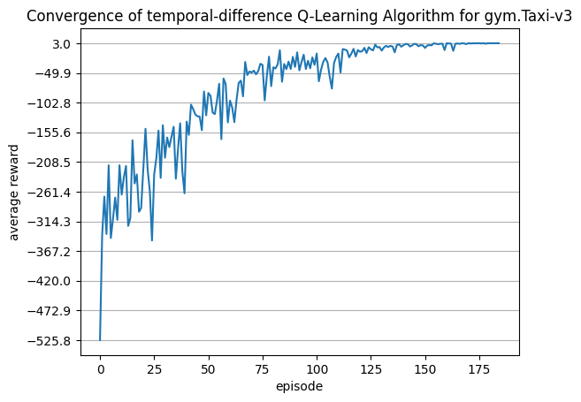

```python
show_convergence(reward_sum)
```

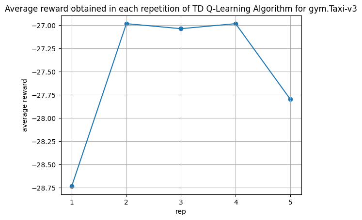

```python
show_average_reward(reward_sum)
```

#### Q-Learning with a dynamic $\alpha$

```python
reward_sum = do_learning(does_lr_decay=True)
```

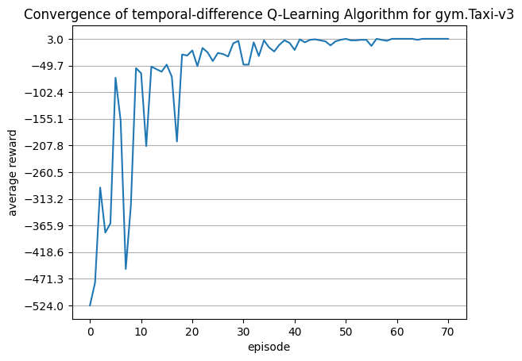

```python
show_convergence(reward_sum)
```

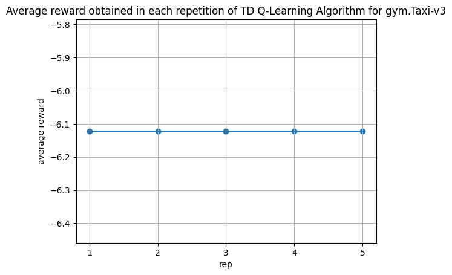

```python
show_average_reward(reward_sum)
```

### Question 10: A graphical representation of an agent taking the learnt optimal policy.

If `DO_RENDER == True`, the following procedure will run:

- First, training an agent once more by Q-Learning with dynamic $\alpha$,
- Then rendering it graphically.

```python
if DO_RENDER:
    env = gym.wrappers.TimeLimit(gym.make('Taxi-v3'), TIME_LIMIT)
    agent = QLearningAgent(env, EPSILON, 1, DISCOUNT, STUDENT_NUM)
    for episode in range(EPISODES):
        state, terminated, truncated = agent.reset()
        while not (terminated or truncated):
            action = agent.choose_action(state)
            next_state, reward, terminated, truncated = agent.take_action(action)

            agent.update_q_table(state, action, next_state, reward)
            agent.decay_epsilon(episode)
            agent.decrease_learning_rate(episode)

            state = next_state

    genv = gym.make('Taxi-v3', render_mode='human')
    genv.metadata['render_fps'] = RENDER_FPS

    state, _ = genv.reset(seed=STUDENT_NUM)
    terminated, truncated = False, False
    try:
        while not (terminated or truncated):
            action = agent.choose_action(state)
            state, _, terminated, truncated, _ = genv.step(action)
            genv.render()
    finally:
        genv.close()
```